# Assignment 4: Final Coursework

1/14/2019

## Introduction

This is a shiny app intended to demonstrate how the value of a gradient changes the slope/shape of a linear plot, and it is aimed for educational purposes.

### *The Maths*

As we know the equation for gradient of a linear equation is:

\[\delta = \frac{Y_2 - Y_1}{X_2 - X_1}\]

Which can be interpreted how much Y changes with each change of 1 unit of X

The app will show students when the bigger the gradient the steeper the slop of the line, and conversely the smaller the gradient the shallower the line

## The Code

The app is created using `shinyapp` as web application. The student is asked to move a slider which sets the gradient which is then passed to shiny server as `input$grad`. This then used to calculate data as follows:

```r
    #We'll assume the gradient slider is set to 5
    grad<-5
    x    <- -5:5
    y    <- x*grad

    #Then we plot the graph as follows:
    plot(x,y,col='red', type="l", ylim=c(-25,25), lwd=3, xaxt="n", yaxt="n")
    axis(1, pos=0)
    axis(2, pos=0)
    abline(v=0, h=0)
```

Please refer for next slide to check result of this plot

## The plot

Once the code runs as per previous slide the a line will be plot and displayed as follows:

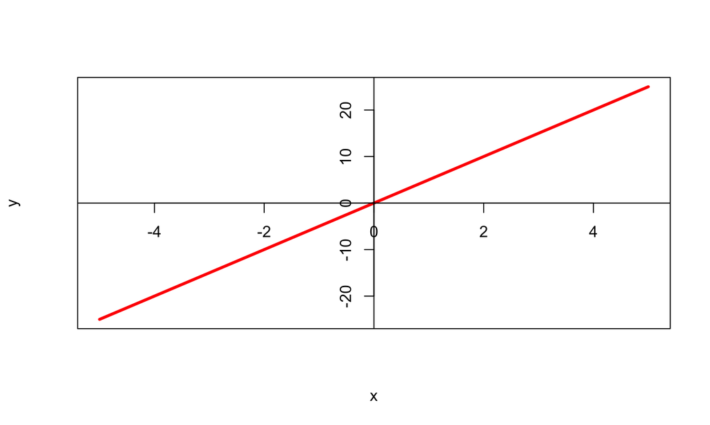

## Check the webapp

To check the app please the following link:

https://omarnooreddin.shinyapps.io/gradientexplained/

For the code, please refer to the github repo:

https://github.com/omarmn/DataScience_JH_Coursera_Assignments/tree/master/9.DevelopingDataProdcts/FinalCourseWork